# Machine Learning Engineer Nanodegree

## Project: Household Classification for Cash Transfer

## Exploring the Data

We'll start by importing the dataset and peeking into the imported data. Going forward in the document, the following terms and abbreviations will be used:

- HH - Household
- CT - Cash Transfer
- Group/Household group - These are partitioned into 2 groups; group 1 which receive regular payment and group 2 which are paid on emergency scenarios

**Note** in our case *group 1 == True*, *group 2 == False*

```python
# Import libraries necessary for this project
import numpy as np
import pandas as pd
from time import time
from IPython.display import display # Allows the use of display() for DataFrames
import matplotlib.pyplot as pl

# Import supplementary visualization code visuals.py
import visuals as vs

# Pretty display for notebooks
%matplotlib inline

# Load the Census dataset
data = pd.read_csv("mlnd-ds-2.csv")

# Success - Display the first record
display(data.head())
```

|  | Gender | Age | Attended_school | Work_last_7days | Chronic_illness | Disabled | YearsChronicallyIll | WealthGroup | Resident_Provider | Polygamous | Children_Under_15 | kids_under_15_in_settlement | wives_in_settlement | spouses_outside_hh | HHGroup | Toilet | Drinking_water | Land_Ha |
| --- | --- | --- | --- | --- | --- | --- | --- | --- | --- | --- | --- | --- | --- | --- | --- | --- | --- | --- |
| 0 | Male | 62 | Never | Herding-Worked on own/family agri. holding | 0 | 1 | 0 | Very Poor | All live here all of the time | 0.0 | 0.0 | 0.0 | 0.0 | 0.0 | True | Bush-None | Tube well/borehole with pump | 0 |
| 1 | Female | 75 | Never | Other | 0 | 0 | 0 | Very Poor | All live here all of the time | 0.0 | 0.0 | 0.0 | 0.0 | 0.0 | False | Bush-None | Tube well/borehole with pump | 0 |
| 2 | Male | 54 | Yes, but now now | Worked on own/family business | 0 | 0 | 0 | Very Poor | All live here all of the time | 0.0 | 0.0 | 0.0 | 0.0 | 0.0 | False | Covered pit latrine | Tube well/borehole with pump | 0 |
| 3 | Male | 48 | Never | Herding-Worked on own/family agri. holding | 0 | 0 | 0 | Very Poor | All live here all of the time | 0.0 | 0.0 | 0.0 | 0.0 | 0.0 | False | Bush-None | Tube well/borehole with pump | 0 |
| 4 | Female | 35 | Never | Worked on own/family business | 0 | 0 | 0 | Very Poor | All live here all of the time | 0.0 | 0.0 | 0.0 | 0.0 | 0.0 | False | Bush-None | Tube well/borehole with pump | 0 |

### Data Exploration

A cursory investigation of the dataset will determine how many HH fit into either group, This will give us an indication percentage of HH in group 1 versus HH in group 2, we will be computing the following:

- The total number of records, `'n_records'`
- HH in group 1, `'hh_g1'`.
- HH in group 2, `'hh_g2'`.
- Percentage HH in group 1, `'greater_percent'`.

```python
n_records = len(data['HHGroup'])

hh_g1 = len(np.where(data['HHGroup'] == True)[0])
hh_g2 = len(np.where(data['HHGroup'] == False)[0])
hh_1_perc = float(hh_g1) / float(n_records) * 100
hh_2_perc = float(hh_g2) / float(n_records) * 100

# Print the results

print("Total number of records: {}".format(n_records))
print("HH in group 1: {}".format(hh_g1))
print("HH in group 2: {}".format(hh_g2))
print("Percentage HH in group 1: {:,.2f}%".format(hh_1_perc))
print("Percentage HH in group 2: {:,.2f}%".format(hh_2_perc))
```

```
Total number of records: 100000
HH in group 1: 27245
HH in group 2: 72755
Percentage HH in group 1: 27.25%
Percentage HH in group 2: 72.76%
```

**Features Exploration**

- **Gender**: Male, Female
- **Age**: continuous.
- **Attended_school**: Currently attending, Never, Yes but not now, SKIP
- **Work_last_7days** (had work at time of registration ?): SKIP, Worked for pay, On leave, Sick leave, Worked on own/family, business, Herding-Worked on own/family agri. holding, Seeking work, Doing nothing, Retired, Homemaker, Full-time, student, In capacitated, Other
- **Chronic_illness**: 0 - false, 1- true, 2-skip
- **Disabled**: 0- false, 1- true
- **YearsChronicallyIll**: continuous
- **WealthGroup**: Better Off, Middle, Poor, Very Poor
- **Resident_Provider**: SKIP, All live here all of the time, Some live here while others migrate, All migrate together-fully mobile, Inside this household, Outside household but inside compound-settlement, Outside this compound-settlement
- **Polygamous**: discrete
- **Children_Under_15**: discrete
- **kids_under_15_in_settlement**: discrete
- **wives_in_settlement**: discrete
- **spouses_outside_hh**: discrete
- **HHGroup**: categorical
- **Toilet**: Flush toilet, VIP latrine, Uncovered pit latrine, Covered pit latrine, Bucket/pan, Bush-None, Other
- **Drinking_water**: Piped water inside dwelling, Piped water into plot/yard, Public tap, Tube well/borehole with pump, Protected dug well, Protected spring, Rainwater collection, Unprotected dug well/springs, River, Lake, ponds or similar, Water truck/vendor, Bottled water, Other
- **Land_Ha**: discrete

### Distributions

View age distributions before data preprocessing. Changes at the preprocessing stage are likely to affect the age distribution

```python
# check for records with *YearsChronicallyIll*
t_yrsill = len(np.where(data['YearsChronicallyIll'] > 0)[0])
t_age = len(np.where(data['Age'] > 0)[0])
N = len(data)

print("Percentage of dataset records of YearsChronicallyIll feature {:.2f}%, age {:.2f}%".format(t_yrsill/N*100, t_age/N*100))

#checking dataset stats
print(data.describe())
```

```
Percentage of dataset records of YearsChronicallyIll feature 1.54%, age 100.00%
                 Age  Chronic_illness       Disabled  YearsChronicallyIll  \
count  100000.000000    100000.000000  100000.000000        100000.000000
mean       44.969680         0.018830       0.023450             0.113840
std        16.113227         0.135999       0.151329             1.343986
min         4.000000         0.000000       0.000000             0.000000
25%        32.000000         0.000000       0.000000             0.000000
50%        42.000000         0.000000       0.000000             0.000000
75%        57.000000         0.000000       0.000000             0.000000
max       124.000000         2.000000       1.000000            70.000000

         Polygamous  Children_Under_15  kids_under_15_in_settlement  \
count  98360.000000       95019.000000                 95019.000000
mean       0.126718           0.047033                     0.025311
std        0.349180           0.507420                     0.340774
min       -2.000000           0.000000                     0.000000
25%        0.000000           0.000000                     0.000000
50%        0.000000           0.000000                     0.000000
75%        0.000000           0.000000                     0.000000
max       10.000000          19.000000                    15.000000

       wives_in_settlement  spouses_outside_hh   Land_Ha
count         95019.000000        95019.000000  100000.0
mean              0.014944            0.034298       0.0
std               0.151844            0.227626       0.0
min               0.000000            0.000000       0.0
25%               0.000000            0.000000       0.0
50%               0.000000            0.000000       0.0
75%               0.000000            0.000000       0.0
max               5.000000            8.000000       0.0
```

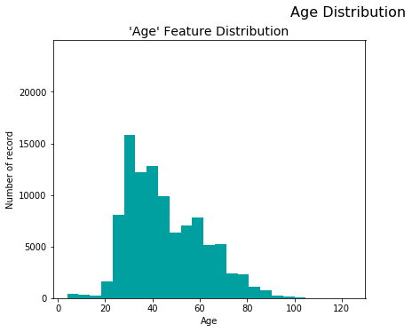

```python
vs.agedist(data)
```

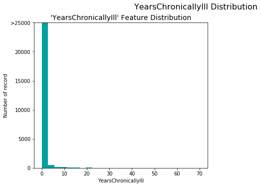

```python
# Create figure
fig = pl.figure(figsize = (11,5));
feature = 'YearsChronicallyIll'

ax = fig.add_subplot(1, 2, 1)
ax.hist(data[feature], bins = 25, color = '#00A0A0')
ax.set_title("'%s' Feature Distribution"%(feature), fontsize = 14)
#pl.xlim((1, 200))
ax.set_xlabel('YearsChronicallyIll')
ax.set_ylabel('Number of record')
ax.set_ylim((0, 25000))
ax.set_yticks([0, 5000, 10000, 15000, 20000, 25000])
ax.set_yticklabels([0, 5000, 10000, 15000, 20000, '>25000'])

# Plot aesthetics
fig.suptitle("YearsChronicallyIll Distribution", fontsize = 16, y = 1.03)

fig.tight_layout()
fig.show()
```

## Preparing the Data

### Check for missing data

We will preprocess using the MinMaxScaler feature for numerical values. We'll also drop features with missing data, shown by the 'SKIP' pattern.

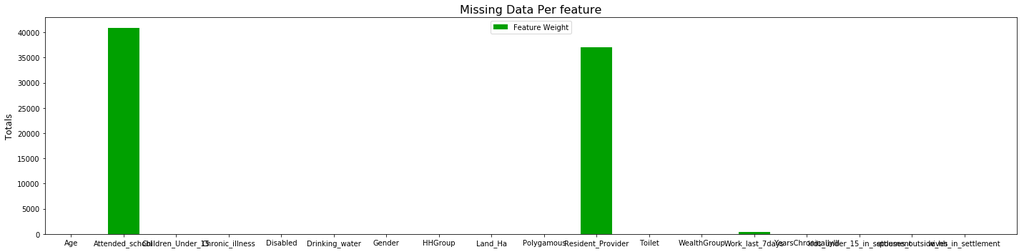

```python
import matplotlib.pyplot as pl

#checking for skips in data
columns = data.columns
skipds = {}

for col in data.columns:
    skipds[col] = [np.count_nonzero(data[col].astype(str) == 'SKIP')]
    #print ("Missing data in {} = {} ".format(col, skipds[col][0]))

skip_df = pd.DataFrame(data = skipds)

columns = skip_df.columns
values = skip_df.values[0]
rng = len(skip_df.columns)

#print(columns, values, rng)
# Create plot
fig = pl.figure(figsize = (20,5))
pl.title("Missing Data Per feature", fontsize = 16)

pl.bar(np.arange(rng), values, width = 0.6, align="center", color = '#00A000', label = "Feature Weight")

pl.xticks(np.arange(rng), columns)
pl.xlim((-0.5, 18))
pl.ylabel("Totals", fontsize = 12)
pl.xlabel("", fontsize = 12)

pl.legend(loc = 'upper center')
pl.tight_layout()
pl.show()
```

Note that Attended_school and Resident_Provider features have a non trivial amount of missing data. These features will therefore be dropped

```python
#drop target label and features with non-trivial missing data
fd = data.drop(['Attended_school', 'Resident_Provider'], axis=1)

#convert skip to NaN
fd2 = fd.replace('SKIP', np.NaN)

fd2['Chronic_illness'].replace(2, np.NaN)
fd2['Polygamous'].replace(-2, np.NaN)

fd2.dropna(inplace=True)

#display(fd2.isnull().any())

hhgroup_raw = fd2['HHGroup']
fd2 = fd2.drop('HHGroup',axis=1)
#display(fd2.head())

print("Total records after 1st stage of preprocessing: {}".format(len(fd2)))
#display(fd2[fd2['Age']==43].head())
```

```
Total records after 1st stage of preprocessing: 95000
```

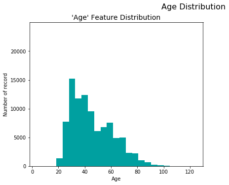

```python
#Distribution of age feature on the normalized dataset
vs.agedist(fd2)
```

Note marginal change in age distribution data above, where data for age < 20 years is no longer represented

### Normalizing numerical features

```python
# Import sklearn.preprocessing.StandardScaler
from sklearn.preprocessing import MinMaxScaler

# Initialize a scaler, then apply it to the features
scaler = MinMaxScaler() # default=(0, 1)
numerical = ['Age','YearsChronicallyIll', 'Polygamous', 'Children_Under_15', 'kids_under_15_in_settlement', 'wives_in_settlement', 'spouses_outside_hh','Land_Ha']

features_minmax_transform = pd.DataFrame(data = fd2)
#display(features_log_minmax_transform[:1])
features_minmax_transform[numerical] = scaler.fit_transform(fd2[numerical])

print(features_minmax_transform.describe())

# records with scaling applied
display(features_minmax_transform.head())
```

```
                Age  Chronic_illness      Disabled  YearsChronicallyIll  \
count  95000.000000     95000.000000  95000.000000         95000.000000
mean       0.344550         0.019000      0.023379             0.001742
std        0.131459         0.136603      0.151105             0.020180
min        0.000000         0.000000      0.000000             0.000000
25%        0.233333         0.000000      0.000000             0.000000
50%        0.316667         0.000000      0.000000             0.000000
75%        0.441667         0.000000      0.000000             0.000000
max        1.000000         2.000000      1.000000             1.000000

         Polygamous  Children_Under_15  kids_under_15_in_settlement  \
count  95000.000000       95000.000000                 95000.000000
mean       0.709519           0.002476                     0.001688
std        0.111633           0.026709                     0.022721
min        0.000000           0.000000                     0.000000
25%        0.666667           0.000000                     0.000000
50%        0.666667           0.000000                     0.000000
75%        0.666667           0.000000                     0.000000
max        1.000000           1.000000                     1.000000

       wives_in_settlement  spouses_outside_hh  Land_Ha
count         95000.000000        95000.000000  95000.0
mean              0.002989            0.004288      0.0
std               0.030372            0.028456      0.0
min               0.000000            0.000000      0.0
25%               0.000000            0.000000      0.0
50%               0.000000            0.000000      0.0
75%               0.000000            0.000000      0.0
max               1.000000            1.000000      0.0
```

|  | Gender | Age | Work_last_7days | Chronic_illness | Disabled | YearsChronicallyIll | WealthGroup | Polygamous | Children_Under_15 | kids_under_15_in_settlement | wives_in_settlement | spouses_outside_hh | Toilet | Drinking_water | Land_Ha |
| --- | --- | --- | --- | --- | --- | --- | --- | --- | --- | --- | --- | --- | --- | --- | --- |
| 0 | Male | 0.483333 | Herding-Worked on own/family agri. holding | 0 | 1 | 0.0 | Very Poor | 0.666667 | 0.0 | 0.0 | 0.0 | 0.0 | Bush-None | Tube well/borehole with pump | 0.0 |
| 1 | Female | 0.591667 | Other | 0 | 0 | 0.0 | Very Poor | 0.666667 | 0.0 | 0.0 | 0.0 | 0.0 | Bush-None | Tube well/borehole with pump | 0.0 |
| 2 | Male | 0.416667 | Worked on own/family business | 0 | 0 | 0.0 | Very Poor | 0.666667 | 0.0 | 0.0 | 0.0 | 0.0 | Covered pit latrine | Tube well/borehole with pump | 0.0 |
| 3 | Male | 0.366667 | Herding-Worked on own/family agri. holding | 0 | 0 | 0.0 | Very Poor | 0.666667 | 0.0 | 0.0 | 0.0 | 0.0 | Bush-None | Tube well/borehole with pump | 0.0 |
| 4 | Female | 0.258333 | Worked on own/family business | 0 | 0 | 0.0 | Very Poor | 0.666667 | 0.0 | 0.0 | 0.0 | 0.0 | Bush-None | Tube well/borehole with pump | 0.0 |

### Categorical Variables conversion

From the table in **Exploring the Data** above, we can see there are several features for each record that are non-numeric. Will convert categorical variables by using the **one-hot encoding** scheme.

We'll also convert the target variable to numerical entries

```python
features_final = pd.get_dummies(features_minmax_transform)
#print features_log_minmax_transform[:1]
hhgroup = hhgroup_raw.replace([False,True],[0,1])

# Print the number of features after one-hot encoding
encoded = list(features_final.columns)
print("{} total features after one-hot encoding.".format(len(encoded)))

# Uncomment the following line to see the encoded feature names
#print (encoded)
display(features_final.head())
```

```
47 total features after one-hot encoding.
```

|  | Age | Chronic_illness | Disabled | YearsChronicallyIll | Polygamous | Children_Under_15 | kids_under_15_in_settlement | wives_in_settlement | spouses_outside_hh | Land_Ha | ... | Drinking_water_Piped water inside dwelling | Drinking_water_Piped water into plot/yard | Drinking_water_Protected dug well | Drinking_water_Protected spring | Drinking_water_Public tap | Drinking_water_Rainwater collection | Drinking_water_River, Lake, ponds or similar | Drinking_water_Tube well/borehole with pump | Drinking_water_Unprotected dug well/springs | Drinking_water_Water truck/vendor |
| --- | --- | --- | --- | --- | --- | --- | --- | --- | --- | --- | --- | --- | --- | --- | --- | --- | --- | --- | --- | --- | --- |
| 0 | 0.483333 | 0 | 1 | 0.0 | 0.666667 | 0.0 | 0.0 | 0.0 | 0.0 | 0.0 | ... | 0 | 0 | 0 | 0 | 0 | 0 | 0 | 1 | 0 | 0 |
| 1 | 0.591667 | 0 | 0 | 0.0 | 0.666667 | 0.0 | 0.0 | 0.0 | 0.0 | 0.0 | ... | 0 | 0 | 0 | 0 | 0 | 0 | 0 | 1 | 0 | 0 |
| 2 | 0.416667 | 0 | 0 | 0.0 | 0.666667 | 0.0 | 0.0 | 0.0 | 0.0 | 0.0 | ... | 0 | 0 | 0 | 0 | 0 | 0 | 0 | 1 | 0 | 0 |
| 3 | 0.366667 | 0 | 0 | 0.0 | 0.666667 | 0.0 | 0.0 | 0.0 | 0.0 | 0.0 | ... | 0 | 0 | 0 | 0 | 0 | 0 | 0 | 1 | 0 | 0 |
| 4 | 0.258333 | 0 | 0 | 0.0 | 0.666667 | 0.0 | 0.0 | 0.0 | 0.0 | 0.0 | ... | 0 | 0 | 0 | 0 | 0 | 0 | 0 | 1 | 0 | 0 |

5 rows × 47 columns

### Split Data

We will split the data (both features and their labels) into training and test sets. 80% of the data will be used for training and 20% for testing.

```python
# Import train_test_split
from sklearn.model_selection import train_test_split

# Split the 'features' and 'income' data into training and testing sets
X_train, X_test, y_train, y_test = train_test_split(features_final,
                                                    hhgroup,
                                                    test_size = 0.2,
                                                    random_state = 0)

print("Training set has {} samples.".format(X_train.shape[0]))
print("Testing set has {} samples.".format(X_test.shape[0]))
```

```
Training set has 76000 samples.
Testing set has 19000 samples.
```

## Evaluating Model Performance

In this section, we will investigate three different algorithms to determine which is best for modeling the data. we'll start with a *naive predictor*.

### Metrics and the Naive Predictor

We'll be employing the fbeta score checking, with emphasis on recall, $\beta > 1$

$$ F_{\beta} = (1 + \beta^2) \cdot \frac{precision \cdot recall}{\left( \beta^2 \cdot precision \right) + recall} $$

#### Definition of accuracy, precision, recall

**Recall(sensitivity)** how many of the true positives were *recalled* (found), number of correct hits found

`[True Positives/(True Positives + False Negatives)]`

**Precision** how many of the returned hits were true positive

`[True Positives/(True Positives + False Positives)]`

**Accuracy** is the fraction of predictions the model got right

`[(True Positives + True Negatives)/Total Number of Records]`

### Question 1 - Naive Predictor Performace

- If we chose a model that always predicted a Household is in group 1, what would that model's accuracy and F-score be on this dataset?

```python
start_time = time()

TP = np.sum(hhgroup)
FP = hhgroup.count() - TP # Specific to the naive case

TN = 0 # No predicted negatives in the naive case
FN = 0 # No predicted negatives in the naive case
bt = 1.5

#print tp_v, fp_v

# TODO: Calculate accuracy, precision and recall
accuracy = float(TP)/len(hhgroup)
recall = float(TP)/(float(TP) + float(FN))
precision = float(TP)/(float(TP) + float(FP))

#print accuracy, recall, precision, len(income)
fscore = (1 + bt**2) * (precision * recall)/((bt**2 * precision) + recall)

# Print the results
print("Naive Predictor: [Accuracy score: {:,.4f}, F-score: {:,.4f}, recall: {:,.4f}, precision: {:,.4f}]"
      .format(accuracy, fscore, recall, precision))

#print(time() - start_time)
```

```
Naive Predictor: [Accuracy score: 0.2744, F-score: 0.5514, recall: 1.0000, precision: 0.2744]
```

### Supervised Learning Models

Tested the following supervised learning algorithms:

- XGBoost
- Decision Trees
- Support Vector Machines (SVM)

```python
from sklearn.metrics import fbeta_score, accuracy_score, precision_score, recall_score

def train_predict(learner, sample_size, X_train, y_train, X_test, y_test):
    '''
    inputs:
       - learner: the learning algorithm to be trained and predicted on
       - sample_size: the size of samples (number) to be drawn from training set
       - X_train: features training set
       - y_train: income training set
       - X_test: features testing set
       - y_test: income testing set
    '''

    results = {}

    start = time() # Get start time
    print (learner)
    learner.fit(X_train[:sample_size], y_train[:sample_size])
    end = time() # Get end time

    results['train_time'] = end - start

    start = time() # Get start time
    predictions_test = learner.predict(X_test)
    predictions_train = learner.predict(X_train[:sample_size])
    end = time() # Get end time

    results['pred_time'] = end - start
    results['acc_train'] = accuracy_score(y_train[:sample_size], predictions_train)
    results['acc_test'] = accuracy_score(y_test, predictions_test)
    results['f_train'] = fbeta_score(y_train[:sample_size], predictions_train, beta=bt)
    results['f_test'] = fbeta_score(y_test, predictions_test, beta=bt)

    # Success
    print("{} trained on {} samples.".format(learner.__class__.__name__, sample_size))

    # Return the results
    return results
```

### Models Evaluation

In the code cell, I will:

- Import and initialize the three models and store them in `'clf_A'`, `'clf_B'`, and `'clf_C'`.
- Calculate the number of records equal to 1%, 10%, and 100% of the training data; Stored as `'samples_1'`, `'samples_10'`, and `'samples_100'` respectively.

```
XGBClassifier(base_score=0.5, booster='gbtree', colsample_bylevel=1,
       colsample_bytree=1, gamma=0, learning_rate=0.1, max_delta_step=0,
       max_depth=3, min_child_weight=1, missing=None, n_estimators=100,
       n_jobs=1, nthread=None, objective='binary:logistic', random_state=0,
       reg_alpha=0, reg_lambda=1, scale_pos_weight=1, seed=None,
       silent=True, subsample=1)
```

```
XGBClassifier trained on 760 samples.
XGBClassifier(base_score=0.5, booster='gbtree', colsample_bylevel=1,
       colsample_bytree=1, gamma=0, learning_rate=0.1, max_delta_step=0,
       max_depth=3, min_child_weight=1, missing=None, n_estimators=100,
       n_jobs=1, nthread=None, objective='binary:logistic', random_state=0,
       reg_alpha=0, reg_lambda=1, scale_pos_weight=1, seed=None,
       silent=True, subsample=1)
```

```
XGBClassifier trained on 7600 samples.
XGBClassifier(base_score=0.5, booster='gbtree', colsample_bylevel=1,
       colsample_bytree=1, gamma=0, learning_rate=0.1, max_delta_step=0,
       max_depth=3, min_child_weight=1, missing=None, n_estimators=100,
       n_jobs=1, nthread=None, objective='binary:logistic', random_state=0,
       reg_alpha=0, reg_lambda=1, scale_pos_weight=1, seed=None,
       silent=True, subsample=1)
```

```
XGBClassifier trained on 76000 samples.
DecisionTreeClassifier(class_weight=None, criterion='gini', max_depth=None,
            max_features=None, max_leaf_nodes=None,
            min_impurity_decrease=0.0, min_impurity_split=None,
            min_samples_leaf=1, min_samples_split=2,
            min_weight_fraction_leaf=0.0, presort=False, random_state=None,
            splitter='best')
DecisionTreeClassifier trained on 760 samples.
DecisionTreeClassifier(class_weight=None, criterion='gini', max_depth=None,
            max_features=None, max_leaf_nodes=None,
            min_impurity_decrease=0.0, min_impurity_split=None,
            min_samples_leaf=1, min_samples_split=2,
            min_weight_fraction_leaf=0.0, presort=False, random_state=None,
            splitter='best')
DecisionTreeClassifier trained on 7600 samples.
DecisionTreeClassifier(class_weight=None, criterion='gini', max_depth=None,
            max_features=None, max_leaf_nodes=None,
            min_impurity_decrease=0.0, min_impurity_split=None,
            min_samples_leaf=1, min_samples_split=2,
            min_weight_fraction_leaf=0.0, presort=False, random_state=None,
            splitter='best')
DecisionTreeClassifier trained on 76000 samples.
SVC(C=1.0, cache_size=200, class_weight=None, coef0=0.0,
  decision_function_shape='ovr', degree=3, gamma='auto', kernel='rbf',
  max_iter=-1, probability=False, random_state=None, shrinking=True,
  tol=0.001, verbose=False)
SVC trained on 760 samples.
SVC(C=1.0, cache_size=200, class_weight=None, coef0=0.0,
  decision_function_shape='ovr', degree=3, gamma='auto', kernel='rbf',
  max_iter=-1, probability=False, random_state=None, shrinking=True,
  tol=0.001, verbose=False)
SVC trained on 7600 samples.
SVC(C=1.0, cache_size=200, class_weight=None, coef0=0.0,
  decision_function_shape='ovr', degree=3, gamma='auto', kernel='rbf',
  max_iter=-1, probability=False, random_state=None, shrinking=True,
  tol=0.001, verbose=False)
SVC trained on 76000 samples.
```

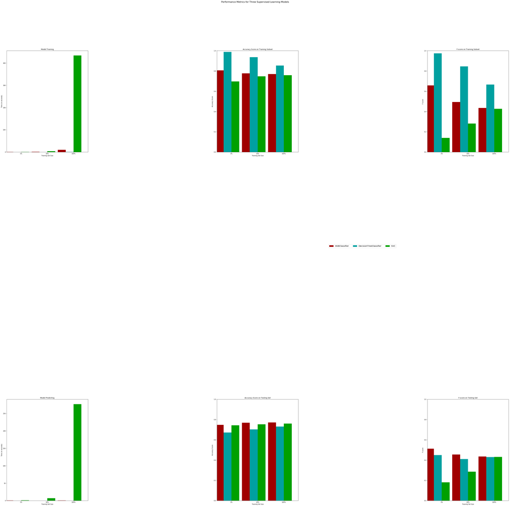

```
738.2926003932953
```

```python
from sklearn.naive_bayes import GaussianNB
from sklearn.tree import DecisionTreeClassifier
from sklearn import svm
from xgboost import XGBClassifier

start_time = time()

clf_A = XGBClassifier()
clf_B = DecisionTreeClassifier()
clf_C = svm.SVC()

samples_100 = len(y_train)
samples_10 = int(float(10)/float(100) * len(y_train))
samples_1 = int(float(1)/float(100) * len(y_train))

# Collect results on the learners
results = {}
for clf in [clf_A, clf_B, clf_C]:
    clf_name = clf.__class__.__name__
    results[clf_name] = {}
    for i, samples in enumerate([samples_1, samples_10, samples_100]):
        results[clf_name][i] = train_predict(clf, samples, X_train, y_train, X_test, y_test)


# Run metrics visualization for the thresupervised learning models chosen
vs.evaluate(results, accuracy, fscore)

print(time() - start_time)
```

### Model Tuning

Use `GridSearchCV` to acquire the best hyperparameters, and `ShuffleSplit` algorithm as the cross-validation algorithm of choice

```python
from sklearn.model_selection import GridSearchCV
from sklearn.metrics import make_scorer
from sklearn.tree import DecisionTreeClassifier
from sklearn.model_selection import ShuffleSplit,cross_val_score

start_time = time()

# TODO: Initialize the classifier
clf = DecisionTreeClassifier() #XGBClassifier() #DecisionTreeClassifier()

parameters = {'max_depth': [5,10,20], 'min_samples_leaf': [5,10,20,30,60,100], 'min_samples_split': range(10,500,20) }
#parameters = {'max_depth': [5,10], 'learning_rate': [0.1, 0.01], 'n_estimators': [100]}

# TODO: Make an fbeta_score scoring object using make_scorer()
scorer = make_scorer(fbeta_score, beta=bt)

cvsets = ShuffleSplit(n_splits = 10, test_size=.2, random_state=100)

#performing gridsearch
grid_obj = GridSearchCV(clf, param_grid = parameters, scoring=scorer, cv = cvsets)

grid_fit = grid_obj.fit(X_train, y_train)

# Get the estimator
best_clf = grid_fit.best_estimator_

# Make predictions using the unoptimized and model
predictions = grid_fit.predict(X_test)
best_predictions = best_clf.predict(X_test)

print(best_clf)

# Report the before-and-afterscores
print("Unoptimized model\n------")
print("Accuracy score on testing data: {:.4f}".format(accuracy_score(y_test, predictions)))
#print("Precision score on testing data: {:.4f}".format(precision_score(y_test, predictions)))
#print("Recall score on testing data: {:.4f}".format(recall_score(y_test, predictions)))
print("F-score on testing data: {:.4f}".format(fbeta_score(y_test, predictions, beta = bt)))

print("\nOptimized Model\n------")
print("Final accuracy score on the testing data: {:.4f}".format(accuracy_score(y_test, best_predictions)))
print("Final F-score on the testing data: {:.4f}".format(fbeta_score(y_test, best_predictions, beta = bt)))

print(time() - start_time)
```

```
DecisionTreeClassifier(class_weight=None, criterion='gini', max_depth=20,
            max_features=None, max_leaf_nodes=None,
            min_impurity_decrease=0.0, min_impurity_split=None,
            min_samples_leaf=5, min_samples_split=250,
            min_weight_fraction_leaf=0.0, presort=False, random_state=None,
            splitter='best')
Unoptimized model
------
Accuracy score on testing data: 0.7675
F-score on testing data: 0.4691

Optimized Model
------
Final accuracy score on the testing data: 0.7675
Final F-score on the testing data: 0.4691
1186.522183418274
```

#### Checking for Robustness

```python
#obtain fold scores
testing_score = best_clf.score(X_test, y_test)

for rnd in [0,50,100,300,700,1000]:
    cv = ShuffleSplit(n_splits = 10, test_size=.2, random_state=rnd)
    scores = cross_val_score(best_clf, features_final, hhgroup, cv=cv)
    print('\nRandom state:{}'.format(rnd),' ******************************************************************')
    print('Testing Score', testing_score)
    # Print the accuracy for each fold:
    print('Accuracy for individual fold', list(scores))
    # And the mean / std of all 5 folds:

    #print(scores.std())
    calcstd = scores.std() * 2
    minscore = scores.mean() - calcstd
    maxscore = scores.mean() + calcstd
    min_accuracy_diff = testing_score - minscore
    max_accuracy_diff = maxscore - testing_score
    print('Accuracy: %0.4f (+/- %0.5f)' % (scores.mean(), calcstd))
    print('Min Accuracy: %0.4f, Max Accuracy: %0.4f'% (minscore, maxscore))
    print('Min Accuracy Diff %0.4f, Max Acc Diff: %0.4f'% (testing_score - minscore, maxscore - testing_score))
    if (max_accuracy_diff < min_accuracy_diff):
        print('Test Accuracy tends towards Fold-Mean Max Accuracy')
    else:
        print('Test Accuracy tends towards Fold-Mean Min Accuracy')
```

```
Random state:0  ******************************************************************
Testing Score 0.7680526315789473
Accuracy for individual fold [0.7680526315789473, 0.7631052631578947, 0.7666315789473684, 0.7648421052631579, 0.7665263157894737, 0.7668421052631579, 0.7636315789473684, 0.7641052631578947, 0.7641052631578947, 0.7680526315789473]
Accuracy: 0.7656 (+/- 0.00350)
Min Accuracy: 0.7621, Max Accuracy: 0.7691
Min Accuracy Diff 0.0060, Max Acc Diff: 0.0010
Test Accuracy tends towards Fold-Mean Max Accuracy

Random state:50  ******************************************************************
Testing Score 0.7680526315789473
Accuracy for individual fold [0.7669473684210526, 0.7683684210526316, 0.7617368421052632, 0.7706842105263157, 0.7667894736842106, 0.766421052631579, 0.7695263157894737, 0.7660526315789473, 0.7637368421052632, 0.7629473684210526]
Accuracy: 0.7663 (+/- 0.00541)
Min Accuracy: 0.7609, Max Accuracy: 0.7717
Min Accuracy Diff 0.0071, Max Acc Diff: 0.0037
Test Accuracy tends towards Fold-Mean Max Accuracy

Random state:100  ******************************************************************
Testing Score 0.7680526315789473
Accuracy for individual fold [0.7652105263157895, 0.7704736842105263, 0.7656315789473684, 0.7703684210526316, 0.7659473684210526, 0.7581578947368421, 0.7674210526315789, 0.7685263157894737, 0.7657894736842106, 0.7593157894736842]
Accuracy: 0.7657 (+/- 0.00784)
Min Accuracy: 0.7578, Max Accuracy: 0.7735
Min Accuracy Diff 0.0102, Max Acc Diff: 0.0055
Test Accuracy tends towards Fold-Mean Max Accuracy

Random state:300  ******************************************************************
Testing Score 0.7680526315789473
Accuracy for individual fold [0.7676315789473684, 0.7643157894736842, 0.759421052631579, 0.7653684210526316, 0.7653157894736842, 0.7602631578947369, 0.7642631578947369, 0.7649473684210526, 0.7693684210526316, 0.7608947368421053]
Accuracy: 0.7642 (+/- 0.00603)
Min Accuracy: 0.7581, Max Accuracy: 0.7702
Min Accuracy Diff 0.0099, Max Acc Diff: 0.0022
Test Accuracy tends towards Fold-Mean Max Accuracy

Random state:700  ******************************************************************
Testing Score 0.7680526315789473
Accuracy for individual fold [0.7648421052631579, 0.7630526315789473, 0.7599473684210526, 0.7689473684210526, 0.7608947368421053, 0.7650526315789473, 0.7663157894736842, 0.7663684210526316, 0.7688421052631579, 0.7626842105263157]
Accuracy: 0.7647 (+/- 0.00582)
Min Accuracy: 0.7589, Max Accuracy: 0.7705
Min Accuracy Diff 0.0092, Max Acc Diff: 0.0025
Test Accuracy tends towards Fold-Mean Max Accuracy

Random state:1000  ******************************************************************
Testing Score 0.7680526315789473
Accuracy for individual fold [0.7665263157894737, 0.7666315789473684, 0.7620526315789473, 0.7607368421052632, 0.7658421052631579, 0.7627368421052632, 0.763578947368421, 0.7661052631578947, 0.7644736842105263, 0.7661052631578947]
Accuracy: 0.7645 (+/- 0.00399)
Min Accuracy: 0.7605, Max Accuracy: 0.7685
Min Accuracy Diff 0.0076, Max Acc Diff: 0.0004
Test Accuracy tends towards Fold-Mean Max Accuracy
```

### Model Final Evaluation

| Metric | Unoptimized Model | Optimized Model |
| --- | --- | --- |
| Accuracy Score | 0.7675 | 0.7675 |
| F-score | 0.4691 | 0.4691 |

### Extracting Feature Importance

We'll be using a classification algorithm which has `feature_importance` implementation. Will set the best classification algorithm (best_clf) obtained above (in our case a decisiontreeclassifier) as the base estimator.

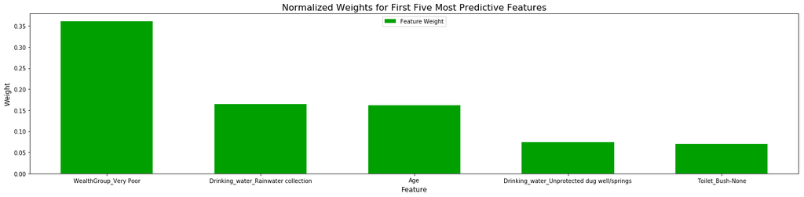

```
'\nfrom xgboost import plot_importance\nfrom matplotlib import pyplot\nplot feature importance\nplot_importance(clf)\npyplot.show()\n'
```

```python
from sklearn.ensemble import AdaBoostClassifier
#from sklearn.tree import DecisionTreeClassifier

clf = AdaBoostClassifier(base_estimator = best_clf) #DecisionTreeClassifier(max_depth=10))

model = clf.fit(X_train, y_train)
importances = clf.estimators_[0].feature_importances_

# Plot
#print(importances)
vs.feature_plot(importances, X_train, y_train)

'''
from xgboost import plot_importance
from matplotlib import pyplot
plot feature importance
plot_importance(clf)
pyplot.show()
'''
```

### Feature Selection

Training *best_clf* on a reduced feature space. We'll check whether reducing the featureset produces equal or better scores

```python
from sklearn.base import clone

# Reduce the feature space
X_train_reduced = X_train[X_train.columns.values[(np.argsort(importances)[::-1])[:5]]]
X_test_reduced = X_test[X_test.columns.values[(np.argsort(importances)[::-1])[:5]]]

# Train on the "best" model found from grid search earlier
clf = (clone(best_clf)).fit(X_train_reduced, y_train)

# Make new predictions
reduced_predictions = clf.predict(X_test_reduced)

# Report scores from the final model using both versions of data
print("Final Model trained on full data\n------")
print("Accuracy on testing data: {:.4f}".format(accuracy_score(y_test, best_predictions)))
print("F-score on testing data: {:.4f}".format(fbeta_score(y_test, best_predictions, beta = bt)))
print("\nFinal Model trained on reduced data\n------")
print("Accuracy on testing data: {:.4f}".format(accuracy_score(y_test, reduced_predictions)))
print("F-score on testing data: {:.4f}".format(fbeta_score(y_test, reduced_predictions, beta = bt)))
```

```
Final Model trained on full data
------
Accuracy on testing data: 0.7675
F-score on testing data: 0.4691

Final Model trained on reduced data
------
Accuracy on testing data: 0.7647
F-score on testing data: 0.4205
```

Performance on the reduced feature space does abit worse than using the full featureset. This was expected since the full featureset has few features to start with. Therefore there's no need to reduce the featureset in our particular case